# A la recherche d'Evergreen

# La longue traîne : un levier pour le trafic

On peut s'en servir pour augmenter le trafic global sur le site :

- L'allonger : ajouter plus de pages « de niche »
- L'épaissir : produire et valoriser des contenus *evergreen*

Pour cela, il faut qu'on connaisse un peu mieux le contenu de cette longue traîne

# Quelques chiffres révélateurs

# Quelques chiffres révélateurs

- 84% des vues sont faites par des articles de moins de 10 jours.
- 50% des vues sont faites par des articles publiés le jour même, 72% si on compte ceux de la veille.

# Tout ça coûte très cher !

Un tel site coûte horriblement cher à produire : des contenus "jetables", éphémères

- Les rédactions doivent réinventer quotidiennement +50% de leur "chiffre d'affaires"
- Re-écriture régulière des mêmes éléments de contexte, à l'occasion de nouveaux événements

On pourrait mitiger cette dépendance à la production quotidienne avec un peu de Evergreen

# A la recherche d'Evergreen

Essayons de trouver ces « vieux » articles qui « rapportent » toujours.

# Les « vieux » contenus du top 2%

#### Quelques articles de plus de 3 mois dans le top 2% (965 articles, 89% des vues)

```python
list_content(subp[subp.age > 90].sort(columns="hits", ascending=False), size=20)
```

[output not shown]

# Trois types de parcours

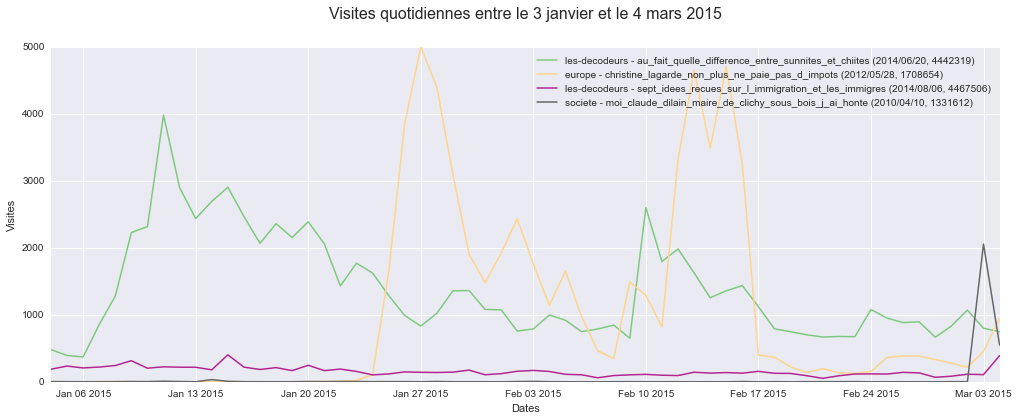

```python
arts = [4442319, 1708654, 4467506, 1331612]
tmplot(arts, hits, content, \
       title="Visites quotidiennes entre le 3 janvier et le 4 mars 2015", \
       ylabel="Visites", \
       xlabel="Dates")
```

- vieux articles référencés par des articles "chauds" et/ou mis à jour récemment
- articles mis en valeur dans les blocs de recommandation pendant quelques jours/semaines
- articles *Evergreen*, qui reviennent actuels de temps à autre

# Un « evergreen indicator »

Si on a accès à la timeline d'un content, on peut élaborer une définition *a posteriori* d'evergreen.

Un article est evergreen sur une période donnée s'il:

- a une médiane de visites élevée
- n'a pas été publié pendant cette période

# Evergreen indicator : un faux-evergreen

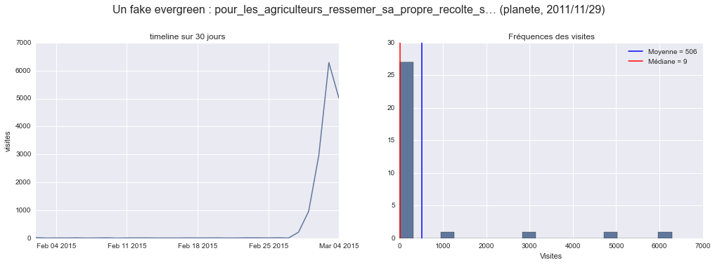

```python
fake_eg = 1610778

info = content.loc[fake_eg]
tm = get_timeline(hits, fake_eg, 30)

f, axarr = plt.subplots(1,2, figsize=(17, 5))
f.suptitle('Un fake evergreen : {}… ({}, {})'.format(info.title[:50] , info.rubrique, info.published), fontsize=16, y=1.05)

tm.plot(ax=axarr[0], title="timeline sur 30 jours")
axarr[0].set_ylabel("visites")

tm_mean = tm.mean()
tm_median = np.median(tm.values)
axarr[1].hist(tm.values, bins=20)
axarr[1].set_title('Fréquences des visites')
axarr[1].set_xlabel('Visites')
axarr[1].axvline(tm_mean, c='b', label="Moyenne = {:.0f}".format(tm_mean))
axarr[1].axvline(tm_median, c='r', label="Médiane = {:.0f}".format(tm_median))
axarr[1].legend()
plt.show()
```

- La moyenne sur le mois est élevée (506 visites)
- La médiane indique que la plupart des jours, l'article n'a presque pas de vues

**Pour les distributions biaisées, la médiane est une meilleure mesure de la tendance centrale que la moyenne.**

# Evergreen indicator : un vrai evergreen

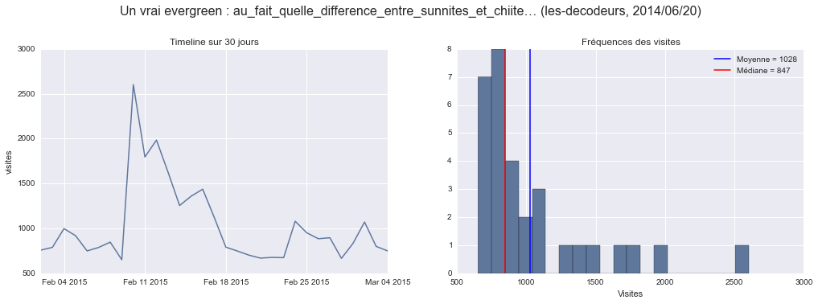

```python
aid = 4442319

info = content.loc[aid]
tm = get_timeline(hits, aid, 30)

f, axarr = plt.subplots(1,2, figsize=(17, 5))
f.suptitle('Un vrai evergreen : {}… ({}, {})'.format(info.title[:50] , info.rubrique, info.published), fontsize=16, y=1.05)

tm.plot(ax=axarr[0], title="Timeline sur 30 jours")
axarr[0].set_ylabel("visites")

tm_mean = tm.mean()
tm_median = np.median(tm.values)
axarr[1].hist(tm.values, bins=20)
axarr[1].set_title('Fréquences des visites')
axarr[1].set_xlabel('Visites')
axarr[1].axvline(tm_mean, c='b', label="Moyenne = {:.0f}".format(tm_mean))
axarr[1].axvline(tm_median, c='r', label="Médiane = {:.0f}".format(tm_median))
axarr[1].legend()
plt.show()
```

# Contenu Evergreen le mercredi 4 mars

```python
def is_evergreen(info, views, refday, minday, threshold = 300):
    tm = get_timeline(views, info.id)
    val = tm[minday:refday].median()
    return val > threshold and info.published_dt < minday

daycontent['evergreen'] = daycontent.apply( \
    is_evergreen, refday = refday, minday = refday - dt.timedelta(days=30), \
    views = hits, threshold=200, axis=1)
```

```python
list_content(daycontent[daycontent['evergreen']].sort(columns="hits", ascending=False), size=11)
```

```
         TITLE                                    RUBRIQUE        DATE PUB.      VIS.
-------  ---------------------------------------  --------------  -----------  ------
1708654  christine_lagarde_non_plus_ne_paie_pas…  europe          2012/05/28      944
4442319  au_fait_quelle_difference_entre_sunnit…  les-decodeurs   2014/06/20      749
4555180  de_charlie_a_dieudonne_jusqu_ou_va_la_…  les-decodeurs   2015/01/14      577
1717261  merah_aurait_decouvert_qu_il_etait_man…  societe         2012/06/12      421
4560905  une_nouvelle_etude_accable_la_cigarett…  sante           2015/01/22      403
4542278  la_carte_a_13_regions_definitivement_a…  politique       2014/12/17      309
4335033  trois_questions_sur_la_hausse_du_smic    societe         2013/12/16      288
4408809  tout_comprendre_sur_votre_fiche_de_pai…  les-decodeurs   2014/04/29      286
4567091  marine_le_pen_en_tete_en_2017_des_sond…  politique       2015/01/30      239
4554839  c_est_charlie_venez_vite_ils_sont_tous…  societe         2015/01/13      198
4353582  en_inde_une_femme_condamnee_a_un_viol_…  asie-pacifiqu…  2014/01/23      195
```

Cette liste comprend deux types d'articles : les vrais-de-vrai, et ceux qui ont du potentiel.

# Evergreen : les vrais de vrai

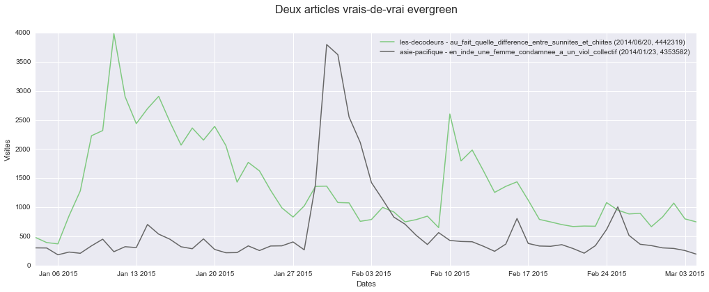

```python
aids = [4442319, 4353582]
tmplot(aids, hits, content, title="Deux articles vrais-de-vrai evergreen", ylabel="Visites", xlabel="Dates")
```

- « vieux » articles (+ 6 mois)
- une *baseline* de visites quotidiennes non négligeable
- des pics quand l'actu s'y prête
- reflètent les centres d'intérêt récurrents des lecteurs (no comments plz ...)

# Pas encore evergreen, mais il y a du potentiel

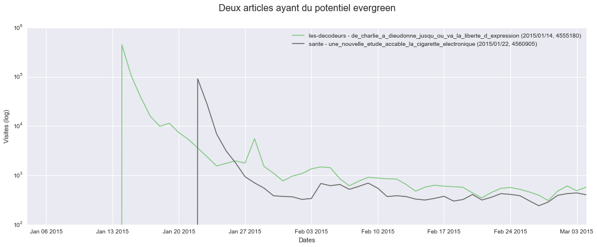

```python
aids = [4555180, 4560905]
tmplot(aids, hits, content, title="Deux articles ayant du potentiel evergreen", ylabel="Visites (log)", xlabel="Dates", lgy=True)
```

- Gardent un trafic considérable et stable après le pic initial
- Indiquent un intérêt des lecteurs pour le sujet sur lequel on peut capitaliser

# Résumons tout ça

- LeMonde.fr : une machine bien huilée pour couvrir (exclusivement?) l'actu
- Il n'y a presque pas d'articles *evergreen*, mais on peut en identifier quelques uns
  - Il faudrait les mettre à jour de temps à autre.
- On peut également identifier les articles presque-*evergreen*
  - Indiquent des sujets pertinents, à traiter
  - Avec un peu d'amour journalistique et de rérérencement, ils pourraient verdir

# Nuances

- Les articles ne sont peut-être pas le contenu le plus propice à du *evergreen*.
- Les vidéos, les grands-formats, les portolios, les posts de blog s'y prêtent davantage
- Il faut leur donner de la visibilité, tout en réservant nos vitrines aux « blockbusters »

# Enjeux

### Ou pourquoi les contenus intemporels sont importants pour un site d'actu

- Augmentation du ROI sur certains contenus
- Lectures récurrentes : l'internaute a une mémoire de poisson rouge
- Acquisition d'audience
- Meuilleure utilisation des efforts journalistiques, via la réutilisation des contenus

Case study: [Refreshing the Evergreen](http://www.vox.com/2015/1/15/7546877/evergreen-experiment)

# La suite

- 1ère étape: rendre accessible la timeline des vues des contenus
- Rendre visibles les contenus *evergreen-ish* et qui auraient besoin d'amour
- Réfléchir à une stratégie de valorisation et de ré-utilisation des ces contenus

Il y a déjà de quoi faire un petit prototype non ?

# Références

### Evergreen

- [StumbleUpon Evergreen Classification Challenge](https://www.kaggle.com/c/stumbleupon)
- The True Power of Evergreen Content:
  - [A Case Study](http://moz.com/blog/the-true-power-of-evergreen-content-a-case-study)
  - [Part Two - Another Year On](http://moz.com/ugc/an-evergreen-content-case-study-part-two-another-year-on)
- [VOX - Refreshing the evergreen](http://www.vox.com/2015/1/15/7546877/evergreen-experiment)
- [VOX - Vox card stacks](http://www.vox.com/cardstacks)

### La longue traîne

- [The long tail (Wikipédia)](http://en.wikipedia.org/wiki/Long_tail)
- [Rethinking the Long Tail Theory: How to Define ‘Hits’ and ‘Niches’](http://knowledge.wharton.upenn.edu/article/rethinking-the-long-tail-theory-how-to-define-hits-and-niches/)